# AIGC5003_Project- Full ML Pipeline_Nishit Rathod_N01586439

Name: Nishit Shaileshbhai Rathod  
Student No: N01586439

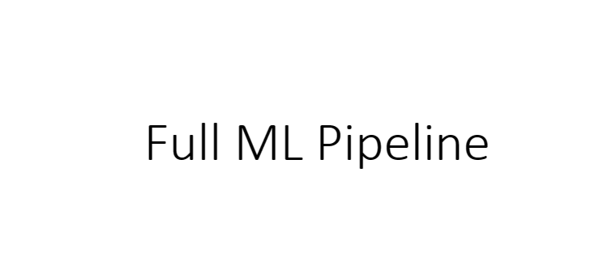

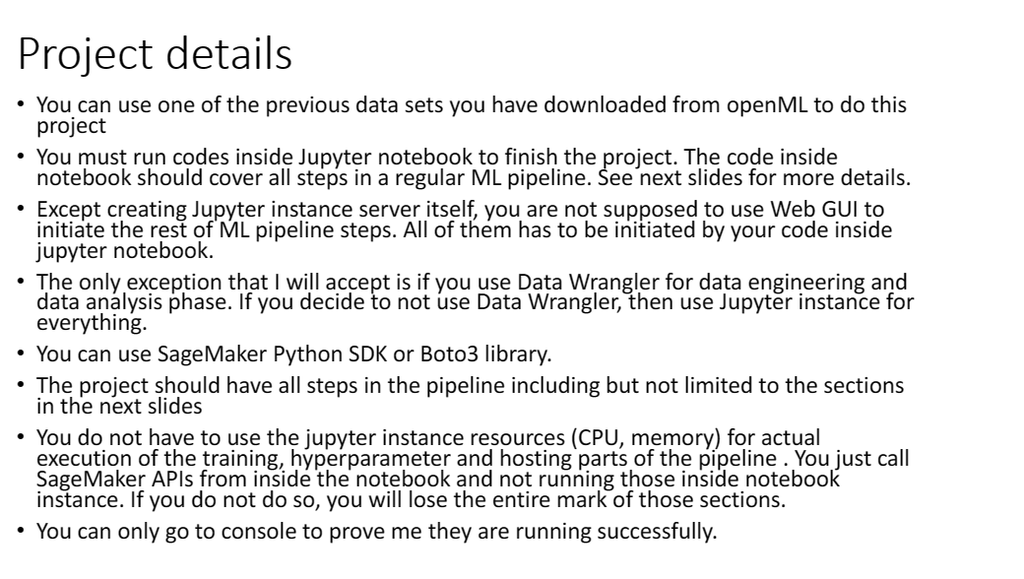

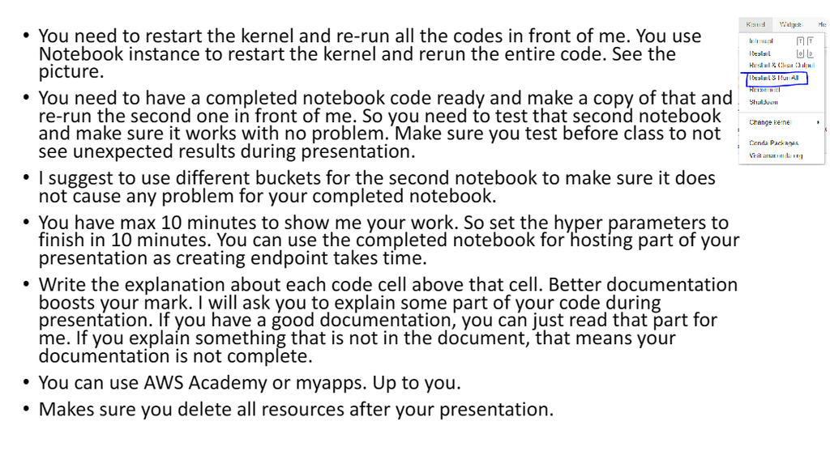

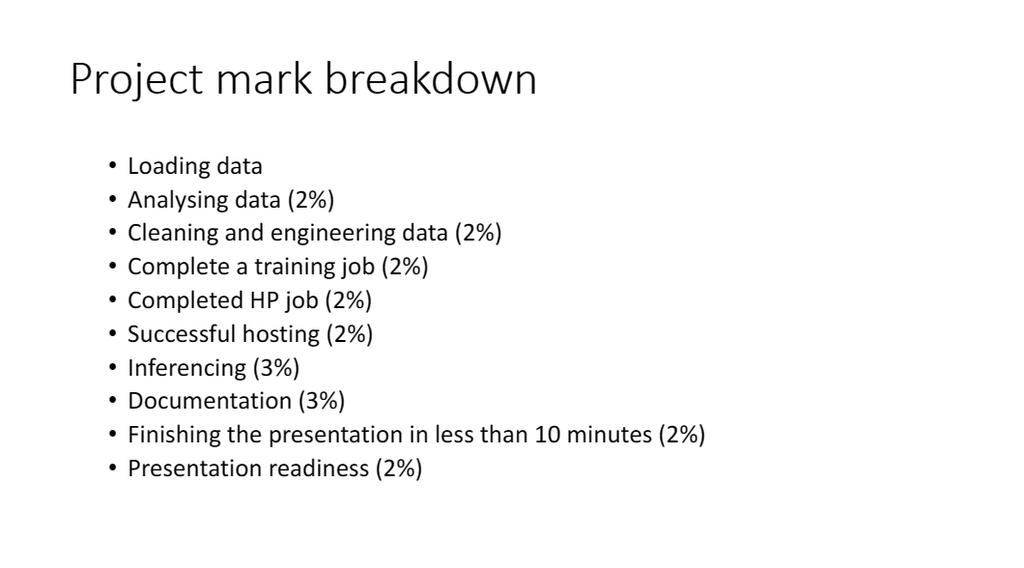

# About The Dataset

## Description

- Author: Volker Lohweg (University of Applied Sciences, Ostwestfalen-Lippe)
- OpenML Source: [OpenML: Bank Note Authentication](https://www.openml.org/search?type=data&status=active&id=1462)

Dataset is about distinguishing genuine and forged banknotes. Data was extracted from images that were taken from genuine and forged banknote-like specimens. For digitization, an industrial camera which is usually used for printing inspection, was used. The final images had 400 x 400 pixels. Due to the object lens and distance to the investigated object gray-scale pictures with a resolution of about 660 dpi was gained. After which Wavelet Transform tool was used to extract features from these images.

# Attribute Information

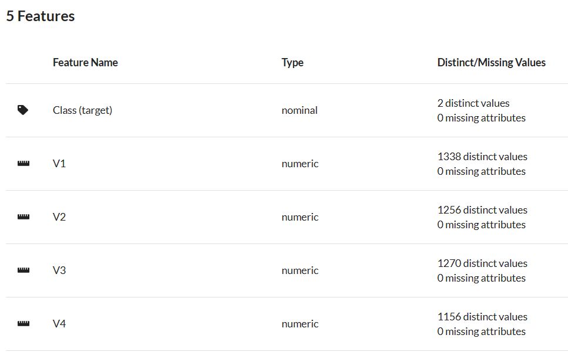

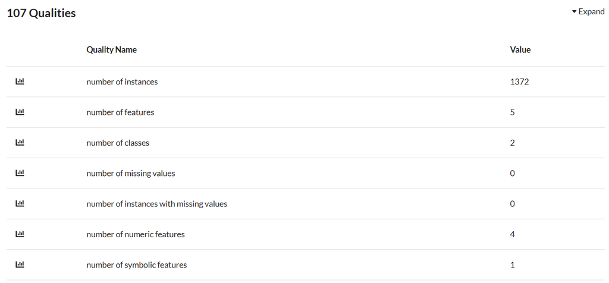

# Importing Python Required Libraries

The below code imports various libraries and defines different functions that are used for machine learning and data analysis tasks. Here is a brief summary of what the code does:

The following libraries are imported: pandas for data manipulation and analysis, numpy for numerical operations, matplotlib and seaborn for data visualization, sagemaker for machine learning on AWS, sklearn for machine learning algorithms and metrics, boto3 for interacting with AWS services.

Some of the functions imported from sklearn are train_test_split, StandardScaler, KNeighborsClassifier, classification_report, confusion_matrix, accuracy_score, roc_curve and roc_auc_score. These functions will be used to train and evaluate machine learning models.

The code also imports get_execution_role, get_image_uri, SKLearn, HyperparameterTuner, and Session from sagemaker. These functions are used to create and manage AWS resources such as training instances, data storage, and deployment.

The code initializes warnings filter to ignore warnings.

Finally, the code defines a Jupyter notebook magic command %matplotlib inline, which is used to display Matplotlib plots in the Jupyter notebook interface.

```python
import pandas as pd
import numpy as np
import matplotlib.pyplot as plt
import seaborn as sns

import os
import re
import io
import time
import json
import sagemaker.amazon.common as smac
import boto3
import sagemaker


from sklearn.model_selection import train_test_split
from sklearn.preprocessing import StandardScaler
from sklearn.neighbors import KNeighborsClassifier
from sklearn.metrics import classification_report
from sklearn.metrics import confusion_matrix
from sklearn.metrics import accuracy_score
from sklearn.metrics import roc_curve, roc_auc_score

from sagemaker import get_execution_role
from sagemaker.amazon.amazon_estimator import get_image_uri
from sagemaker.sklearn.estimator import SKLearn
from sagemaker.tuner import IntegerParameter, CategoricalParameter, ContinuousParameter, HyperparameterTuner
from sagemaker.session import Session
from sagemaker.image_uris import retrieve

%matplotlib inline

import warnings
warnings.filterwarnings("ignore")
```

# Loading Data from S3 Bucket

The above code downloads a file called "Data_Banknote_Authentication.csv" from an S3 bucket named "project-bna-nr". Here is a brief summary of what the code does:

1. The code imports the boto3 library, which is a Python SDK for interacting with AWS services.
2. The code creates an S3 resource object using the boto3.resource() function.
3. The name of the S3 bucket that contains the file to be downloaded is assigned to the variable bucket_name.
4. The name of the file to be downloaded is assigned to the variable file_name.
5. The download_file() function of the S3 bucket resource object is used to download the file from the S3 bucket. The function takes two arguments: the name of the file in the S3 bucket and the local filename to save the file as.

In summary, this code is used to download a file from an S3 bucket using the boto3 library, which is necessary when working with data stored in S3 on AWS.

```python
# Load data from S3 bucket
s3 = boto3.resource('s3')
bucket_name = 'project-bna-nr'
file_name = 'Data_Banknote_Authentication.csv'
s3.Bucket(bucket_name).download_file(file_name, file_name)
```

# Reading the Data

The above code loads the CSV file downloaded in the previous step into a Pandas dataframe named "data". Here is a brief summary of what the code does:

- The code imports the pandas library, which is a popular data manipulation and analysis library for Python.
- The function read_csv() of pandas is used to read the CSV file named "Data_Banknote_Authentication.csv" into a Pandas dataframe. The data is assumed to be in the current working directory.
- The resulting dataframe is assigned to the variable "data".

In summary, this code loads the data from the CSV file into a Pandas dataframe, which is a common way of working with tabular data in Python.

```python
# Load the data into a Pandas dataframe
data = pd.read_csv('Data_Banknote_Authentication.csv')
```

```python
data.head()
```

|  | Variance | Skewness | Curtosis | Entropy | class |
| --- | --- | --- | --- | --- | --- |
| 0 | 3.62160 | 8.6661 | -2.8073 | -0.44699 | 0 |
| 1 | 4.54590 | 8.1674 | -2.4586 | -1.46210 | 0 |
| 2 | 3.86600 | -2.6383 | 1.9242 | 0.10645 | 0 |
| 3 | 3.45660 | 9.5228 | -4.0112 | -3.59440 | 0 |
| 4 | 0.32924 | -4.4552 | 4.5718 | -0.98880 | 0 |

# Data Exploration

```python
data.shape
```

```
(1372, 5)
```

```python
data.columns
```

```
Index(['Variance', 'Skewness', 'Curtosis', 'Entropy', 'class'], dtype='object')
```

```python
data.dtypes
```

```
Variance    float64
Skewness    float64
Curtosis    float64
Entropy     float64
class         int64
dtype: object
```

```python
data.info()
```

```
<class 'pandas.core.frame.DataFrame'>
RangeIndex: 1372 entries, 0 to 1371
Data columns (total 5 columns):
 #   Column    Non-Null Count  Dtype
---  ------    --------------  -----
 0   Variance  1372 non-null   float64
 1   Skewness  1372 non-null   float64
 2   Curtosis  1372 non-null   float64
 3   Entropy   1372 non-null   float64
 4   class     1372 non-null   int64
dtypes: float64(4), int64(1)
memory usage: 53.7 KB
```

```python
data['class'].unique()
```

```
array([0, 1])
```

```python
data['class'].value_counts()
```

```
0    762
1    610
Name: class, dtype: int64
```

```python
data.isnull().sum()
```

```
Variance    0
Skewness    0
Curtosis    0
Entropy     0
class       0
dtype: int64
```

```python
data.describe()
```

|  | Variance | Skewness | Curtosis | Entropy | class |
| --- | --- | --- | --- | --- | --- |
| count | 1372.000000 | 1372.000000 | 1372.000000 | 1372.000000 | 1372.000000 |
| mean | 0.433735 | 1.922353 | 1.397627 | -1.191657 | 0.444606 |
| std | 2.842763 | 5.869047 | 4.310030 | 2.101013 | 0.497103 |
| min | -7.042100 | -13.773100 | -5.286100 | -8.548200 | 0.000000 |
| 25% | -1.773000 | -1.708200 | -1.574975 | -2.413450 | 0.000000 |
| 50% | 0.496180 | 2.319650 | 0.616630 | -0.586650 | 0.000000 |
| 75% | 2.821475 | 6.814625 | 3.179250 | 0.394810 | 1.000000 |
| max | 6.824800 | 12.951600 | 17.927400 | 2.449500 | 1.000000 |

```python
data.corr()
```

|  | Variance | Skewness | Curtosis | Entropy | class |
| --- | --- | --- | --- | --- | --- |
| Variance | 1.000000 | 0.264026 | -0.380850 | 0.276817 | -0.724843 |
| Skewness | 0.264026 | 1.000000 | -0.786895 | -0.526321 | -0.444688 |
| Curtosis | -0.380850 | -0.786895 | 1.000000 | 0.318841 | 0.155883 |
| Entropy | 0.276817 | -0.526321 | 0.318841 | 1.000000 | -0.023424 |
| class | -0.724843 | -0.444688 | 0.155883 | -0.023424 | 1.000000 |

# Exploratory Data Analysis

The above code generates a heatmap to visualize the correlation between the columns in the "data" dataframe using the Seaborn library. Here is a brief summary of what the code does:

1. The code imports the seaborn (as sns) and matplotlib.pyplot (as plt) libraries for data visualization.
2. The heatmap() function of seaborn is used to generate a heatmap of the correlation matrix of the columns in the "data" dataframe. The correlation matrix is computed using the corr() function of pandas. The heatmap() function takes several arguments:
- annot=True adds the correlation values to each cell in the heatmap
- cmap='mako' sets the color map for the heatmap
- linewidths=0.2 sets the width of the lines that separate the cells in the heatmap
1. The size of the figure is adjusted using set_size_inches() function of the figure object returned by the gcf() function of matplotlib.pyplot.
2. The show() function of matplotlib.pyplot displays the heatmap.

In summary, this code generates a heatmap to visualize the correlation between the columns in the "data" dataframe, which is useful for identifying potential relationships between variables in the data.

```
<function matplotlib.pyplot.show(close=None, block=None)>
```

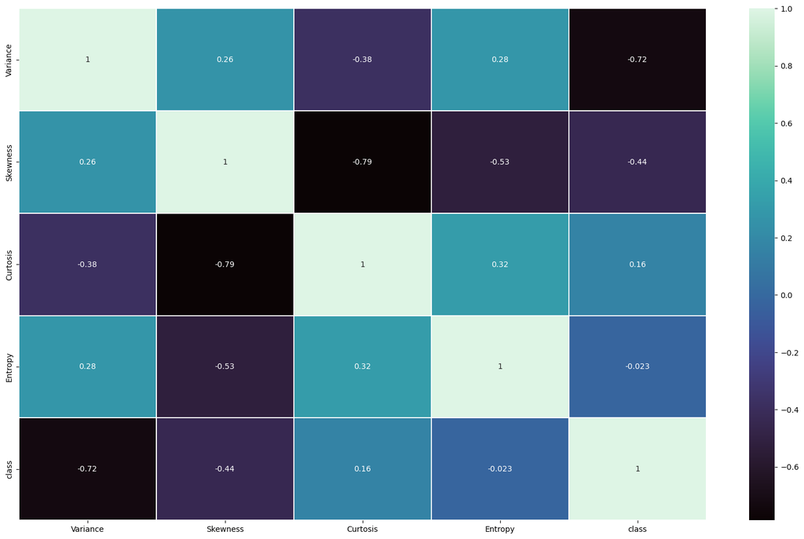

```python
sns.heatmap(data.corr(), annot = True, cmap = 'mako', linewidths = 0.2)
fig = plt.gcf()
fig.set_size_inches(20, 12)
plt.show
```

The above code generates a pairplot to visualize the relationship between pairs of variables in the "data" dataframe using the Seaborn library. Here is a brief summary of what the code does:

1. The code imports the seaborn (as sns) library for data visualization.
2. The pairplot() function of seaborn is used to generate a scatterplot matrix of the variables in the "data" dataframe. The pairplot() function takes several arguments:
- data=data specifies the dataframe to use for generating the pairplot.
- hue='class' specifies the variable to use for coloring the data points based on the value of the 'class' column.
- palette='crest' sets the color palette for the data points.
- height=2 sets the height of each subplot in the pairplot.
- diag_kind='kde' specifies that kernel density estimation plots should be used for the diagonal subplots.
- diag_kws=dict(shade=True) sets the shade parameter to True, which adds shading under the density curves.
- plot_kws=dict(s=10) sets the size of the data points in the scatterplots.
- The xticklabels of the pairplot are removed using the set() function of the pairplot object returned by the pairplot() function.

In summary, this code generates a scatterplot matrix (pairplot) to visualize the relationship between pairs of variables in the "data" dataframe, which is useful for identifying patterns and relationships between variables.

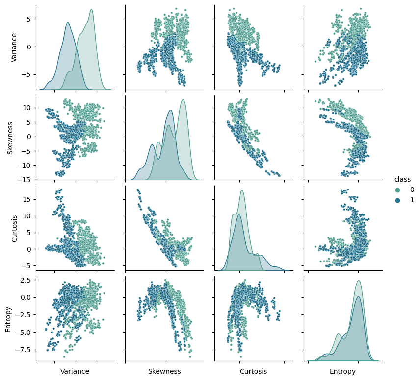

```python
graph = sns.pairplot(data = data, hue = 'class', palette = "crest",
                 height = 2, diag_kind = 'kde', diag_kws = dict(shade=True), plot_kws = dict(s = 10) )
graph.set(xticklabels=[])
```

The above Python code is creating a distribution plot for the columns in a dataset, except for the "class" column.

- The first line creates a list of column names in the dataset, except for the "class" column, by dropping it using the drop() function with the "axis=1" parameter.
- The second line creates a figure with four subplots (one for each column), with a total size of 16 by 4 inches, and adds a title to the plot.
- The for loop iterates over each column in the "cols" list using the "enumerate" function to get the index and the column name.
- In each iteration, a distribution plot is created for the corresponding column using the distplot() function from the Seaborn library, and is added to the corresponding subplot using the "ax" parameter.

The resulting plot will show the distribution of each variable in the dataset, allowing the user to identify patterns and outliers.

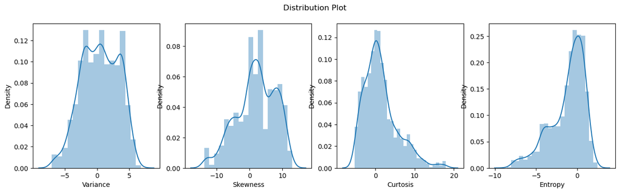

```python
cols = list(data.drop("class", axis=1))

fig, ax = plt.subplots(ncols = 4, figsize=(16, 4))
fig.suptitle("Distribution Plot")

for index, col in enumerate(cols):
    sns.distplot(data[col], ax=ax[index])
```

# Training Testing And Implementing KNN Classifier

The above code performs classification on a dataset using the k-Nearest Neighbors (KNN) algorithm. Here's what it does step by step:

- The first line selects four columns ("Variance", "Skewness", "Curtosis", and "Entropy") from the dataset "data" and assigns them to the variable X. It also selects the "class" column and assigns it to the variable y.
- The second line splits the dataset into training and testing sets. The training set contains 70% of the data, while the testing set contains 30%. The random_state parameter ensures that the split is reproducible.
- The third and fourth lines standardize the data in X_train and X_test using the StandardScaler() function. This scales the features so that they have a mean of 0 and a standard deviation of 1. This is a common preprocessing step for many machine learning algorithms.
- The fifth line creates a KNN classifier object with k=2 and a uniform weighting scheme.
- The sixth line fits the KNN classifier on the training data using the fit() method.
- The seventh line makes predictions on the testing data using the predict() method of the KNN classifier.
- The eighth and ninth lines print the accuracy score of the model and its train and test scores.
- The accuracy score is a measure of how many predictions the model got right out of all the predictions made.

The KNN Classifier Train Score measures the accuracy of the model on the training data, while the KNN Classifier Validation Score measures its accuracy on the testing data. These scores can be used to evaluate the performance of the model and tune its hyperparameters.

```python
X = data[["Variance","Skewness","Curtosis","Entropy"]]
y = data['class']

X_train, X_test, y_train, y_test = train_test_split(X, y, test_size = 0.3, random_state = 0)

# standardize data
scaler = StandardScaler()
X_train = scaler.fit_transform(X_train)
X_test = scaler.transform(X_test)

KNNclassifier = KNeighborsClassifier(n_neighbors = 2, weights ='uniform' )

KNNclassifier.fit(X_train, y_train)
prediction = KNNclassifier.predict(X_test)

print("Accuracy:", accuracy_score(prediction, y_test))
print('KNN Classifier Train Score: ', KNNclassifier.score(X_train, y_train))
print('KNN Classifier Validation Score: ', KNNclassifier.score(X_test, y_test))
```

```
Accuracy: 0.9975728155339806
KNN Classifier Train Score:  1.0
KNN Classifier Validation Score:  0.9975728155339806
```

# Model Evaluation

The classification_report function from the sklearn.metrics module is used to generate a text report of the main classification metrics for a classification model. These metrics include precision, recall, and F1-score for each class in the classification task, as well as the overall accuracy and macro/micro averages of the metrics. Here's what the code does:

The code prints the classification report for the test set predictions made by the KNN classifier trained in the previous code block.

```python
print(classification_report(y_test, prediction))
```

```
              precision    recall  f1-score   support

           0       1.00      1.00      1.00       232
           1       0.99      1.00      1.00       180

    accuracy                           1.00       412
   macro avg       1.00      1.00      1.00       412
weighted avg       1.00      1.00      1.00       412
```

The confusion_matrix function from the sklearn.metrics module is used to create a confusion matrix that shows the number of true positive, true negative, false positive, and false negative predictions made by a classification model. Here's what the code does:

The code creates a confusion matrix for the test set predictions made by the KNN classifier trained in the previous code block. The confusion matrix is stored in the variable CM.

```python
CM = confusion_matrix(y_test, prediction)
CM
```

```
array([[231,   1],
       [  0, 180]])
```

- The first line sets the font scale to 1.4 to make the text in the heatmap larger and more readable.
- The second line creates the heatmap using the sns.heatmap function. The annot parameter is set to True to display the numbers in each cell of the heatmap. The fmt parameter is set to 'g' to format the numbers in a general format. The cmap parameter is set to 'Blues' to use a blue color scheme for the heatmap. The annot_kws parameter is used to set the font size of the numbers in the heatmap to 16.
- The third line sets the title of the plot to "Confusion Matrix".
- The fourth line sets the label for the x-axis to "Predicted".
- The fifth line sets the label for the y-axis to "Actual".
- The sixth line displays the plot using the plt.show() function.

The resulting plot will show a heatmap with the number of true positives, false positives, true negatives, and false negatives in the different cells of the matrix, where the actual class is shown on the y-axis and the predicted class is shown on the x-axis. The heatmap can help visualize the model's performance by highlighting areas where there are more errors in its predictions.

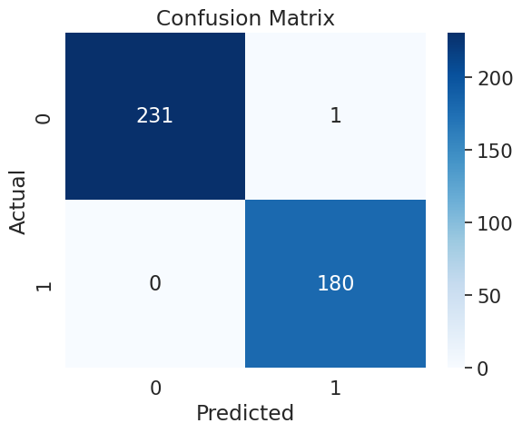

```python
# plot confusion matrix
sns.set(font_scale = 1.4)
sns.heatmap(CM, annot = True, fmt = 'g', cmap = 'Blues', annot_kws = {"size": 16})
plt.title('Confusion Matrix')
plt.xlabel('Predicted')
plt.ylabel('Actual')
plt.show()
```

The code above generates an ROC (Receiver Operating Characteristic) curve to evaluate the performance of the KNN classifier on the test set. Here's how it works:

- The first line uses the predict_proba method of the KNN classifier to get the predicted probabilities of the positive class (banknote is counterfeit) for the test set. The [:, 1] indexing is used to extract only the probabilities of the positive class.
- The second line calculates the ROC curve using the roc_curve function from the sklearn.metrics module. This function takes the true labels (y_test) and predicted probabilities (y_pred_proba) as inputs and returns three arrays: fpr (false positive rate), tpr (true positive rate), and thresholds. The false positive rate is defined as the number of false positives divided by the sum of true negatives and false positives, while the true positive rate is defined as the number of true positives divided by the sum of true positives and false negatives.
- The third line calculates the AUC (Area Under the Curve) score of the ROC curve using the roc_auc_score function from the sklearn.metrics module. The AUC score is a measure of how well the classifier can distinguish between the positive and negative classes. An AUC score of 1.0 indicates perfect performance, while a score of 0.5 indicates random performance.
- The fourth to seventh lines plot the ROC curve.

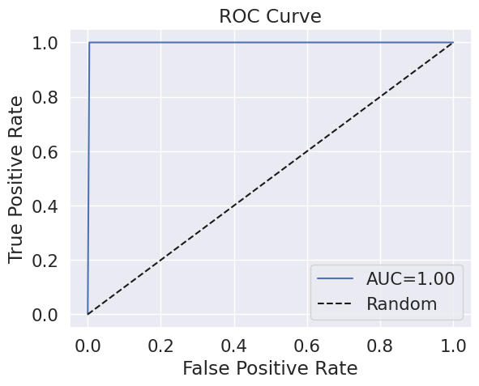

```python
# Get the predicted probabilities of the positive class on the testing data
y_pred_proba = KNNclassifier.predict_proba(X_test)[:, 1]
# Calculate the ROC curve and AUC score
fpr, tpr, thresholds = roc_curve(y_test, y_pred_proba)
auc_score = roc_auc_score(y_test, y_pred_proba)
# Plot the ROC curve
plt.plot(fpr, tpr, label = f'AUC={auc_score:.2f}')
plt.plot([0, 1], [0, 1], 'k--', label = 'Random')
plt.xlabel('False Positive Rate')
plt.ylabel('True Positive Rate')
plt.title('ROC Curve')
plt.legend()
plt.show()
```

# Preparing Data for performing Training, Hyper parameter tuning, Creating Endpoint and establishing Serverless Inferencing.

Amazon SageMaker is a fully-managed service that provides developers and data scientists with the ability to build, train, and deploy machine learning models quickly and easily. It offers a range of features and tools that allow users to streamline the machine learning development process, from data labeling and preprocessing to model training and deployment. In this context, let's discuss the following terms with respect to AWS SageMaker:

1. Training job: A training job is the process of running a machine learning algorithm on a dataset to create a trained model. In AWS SageMaker, you can create a training job by providing your data and code to the platform, which then spins up a cluster of machines to run the job. During the training process, SageMaker automatically manages the hardware resources and optimizes the training process to achieve the best possible performance.
2. Hyperparameter tuning: Hyperparameters are parameters that control the behavior of the machine learning algorithm, such as the learning rate, batch size, and number of hidden layers. Hyperparameter tuning is the process of finding the best set of hyperparameters for a given machine learning problem. In AWS SageMaker, you can use the built-in hyperparameter tuning feature to automatically search for the best set of hyperparameters for your model. SageMaker performs the tuning process by running multiple training jobs with different hyperparameter values and selecting the best one based on a defined metric, such as accuracy or F1 score.
3. Inferencing: Inferencing is the process of using a trained machine learning model to make predictions on new data. In AWS SageMaker, you can use the trained model to perform inferencing on new data by deploying the model to an endpoint. The endpoint provides a web service interface that allows you to send requests to the model and receive predictions in real-time.
4. Endpoint: An endpoint is a web service interface that allows you to deploy a trained machine learning model to the cloud and make predictions on new data. In AWS SageMaker, you can create an endpoint by deploying your trained model to a SageMaker-managed infrastructure. Once the endpoint is created, you can use it to perform real-time inferencing on new data.
5. Serverless Inference: Serverless inference is a deployment option for machine learning models that allows you to perform inferencing without having to manage servers or infrastructure. In AWS SageMaker, you can use the serverless inference feature to deploy your trained model to an AWS Lambda function, which can then be invoked via an API Gateway endpoint. This approach allows you to scale your inferencing workload dynamically based on demand and eliminates the need for managing servers or infrastructure.

In summary, AWS SageMaker provides a range of features and tools that allow you to streamline the machine learning development process, from training and hyperparameter tuning to inferencing and deployment. The platform automates many of the tedious and time-consuming tasks associated with machine learning development, allowing you to focus on building and improving your models. With its built-in integration with other AWS services and support for popular machine learning frameworks, AWS SageMaker is a powerful tool for data scientists and developers looking to build and deploy machine learning models at scale.

```python
data.head()
```

|  | Variance | Skewness | Curtosis | Entropy | class |
| --- | --- | --- | --- | --- | --- |
| 0 | 3.62160 | 8.6661 | -2.8073 | -0.44699 | 0 |
| 1 | 4.54590 | 8.1674 | -2.4586 | -1.46210 | 0 |
| 2 | 3.86600 | -2.6383 | 1.9242 | 0.10645 | 0 |
| 3 | 3.45660 | 9.5228 | -4.0112 | -3.59440 | 0 |
| 4 | 0.32924 | -4.4552 | 4.5718 | -0.98880 | 0 |

```python
data2 = pd.read_csv('Data_Banknote_Authentication.csv', header = None)
```

```python
# Drop the first row
data2 = data2.drop(data2.index[0])
```

```python
data2.head()
```

|  | 0 | 1 | 2 | 3 | 4 |
| --- | --- | --- | --- | --- | --- |
| 1 | 3.6216 | 8.6661 | -2.8073 | -0.44699 | 0 |
| 2 | 4.5459 | 8.1674 | -2.4586 | -1.4621 | 0 |
| 3 | 3.866 | -2.6383 | 1.9242 | 0.10645 | 0 |
| 4 | 3.4566 | 9.5228 | -4.0112 | -3.5944 | 0 |
| 5 | 0.32924 | -4.4552 | 4.5718 | -0.9888 | 0 |

```python
# Split the data into training and testing sets
train_data, test_data = train_test_split(data2, test_size = 0.3, random_state = 42)
```

```python
train_data
```

|  | 0 | 1 | 2 | 3 | 4 |
| --- | --- | --- | --- | --- | --- |
| 880 | -0.56877 | 1.4174 | -1.4252 | -1.1246 | 1 |
| 784 | 0.47368 | 3.3605 | -4.5064 | -4.0431 | 1 |
| 606 | 1.0652 | 8.3682 | -1.4004 | -1.6509 | 0 |
| 1254 | -4.5531 | -12.5854 | 15.4417 | -1.4983 | 1 |
| 498 | -0.048008 | -1.6037 | 8.4756 | 0.75558 | 0 |
| ... | ... | ... | ... | ... | ... |
| 1096 | 1.164 | 3.913 | -4.5544 | -3.8672 | 1 |
| 1131 | -2.2918 | -7.257 | 7.9597 | 0.9211 | 1 |
| 1295 | -7.0364 | 9.2931 | 0.16594 | -4.5396 | 1 |
| 861 | -3.4605 | 2.6901 | 0.16165 | -1.0224 | 1 |
| 1127 | -3.3582 | -7.2404 | 11.4419 | -0.57113 | 1 |

960 rows × 5 columns

```python
test_data
```

|  | 0 | 1 | 2 | 3 | 4 |
| --- | --- | --- | --- | --- | --- |
| 431 | 1.5691 | 6.3465 | -0.1828 | -2.4099 | 0 |
| 589 | -0.27802 | 8.1881 | -3.1338 | -2.5276 | 0 |
| 297 | 0.051979 | 7.0521 | -2.0541 | -3.1508 | 0 |
| 185 | -1.7559 | 11.9459 | 3.0946 | -4.8978 | 0 |
| 245 | 2.4287 | 9.3821 | -3.2477 | -1.4543 | 0 |
| ... | ... | ... | ... | ... | ... |
| 844 | -0.52645 | -0.24832 | -0.45613 | 0.41938 | 1 |
| 495 | 2.5698 | -4.4076 | 5.9856 | 0.078002 | 0 |
| 1033 | 0.16358 | -3.3584 | 1.3749 | 1.3569 | 1 |
| 711 | 2.4012 | 1.6223 | 3.0312 | 0.71679 | 0 |
| 334 | 3.0009 | 5.8126 | -2.2306 | -0.66553 | 0 |

412 rows × 5 columns

- Shifting the class in front as that is the pre requirement of XGBOOST ALGORITHM

```python
# get the last column name
last_column_name = test_data.columns[-1]

# reorder the columns
test_data = test_data[[last_column_name] + list(test_data.columns[:-1])]

# print the modified dataframe
print(test_data)
```

```
      4         0         1         2         3
431   0    1.5691    6.3465   -0.1828   -2.4099
589   0  -0.27802    8.1881   -3.1338   -2.5276
297   0  0.051979    7.0521   -2.0541   -3.1508
185   0   -1.7559   11.9459    3.0946   -4.8978
245   0    2.4287    9.3821   -3.2477   -1.4543
...  ..       ...       ...       ...       ...
844   1  -0.52645  -0.24832  -0.45613   0.41938
495   0    2.5698   -4.4076    5.9856  0.078002
1033  1   0.16358   -3.3584    1.3749    1.3569
711   0    2.4012    1.6223    3.0312   0.71679
334   0    3.0009    5.8126   -2.2306  -0.66553

[412 rows x 5 columns]
```

```python
# get the last column name
last_column_name1 = train_data.columns[-1]

# reorder the columns
train_data = train_data[[last_column_name1] + list(train_data.columns[:-1])]

# print the modified dataframe
print(train_data)
```

```
      4          0         1        2         3
880   1   -0.56877    1.4174  -1.4252   -1.1246
784   1    0.47368    3.3605  -4.5064   -4.0431
606   0     1.0652    8.3682  -1.4004   -1.6509
1254  1    -4.5531  -12.5854  15.4417   -1.4983
498   0  -0.048008   -1.6037   8.4756   0.75558
...  ..        ...       ...      ...       ...
1096  1      1.164     3.913  -4.5544   -3.8672
1131  1    -2.2918    -7.257   7.9597    0.9211
1295  1    -7.0364    9.2931  0.16594   -4.5396
861   1    -3.4605    2.6901  0.16165   -1.0224
1127  1    -3.3582   -7.2404  11.4419  -0.57113

[960 rows x 5 columns]
```

```python
test_data.to_csv("projtest.csv", header=False, index = False)
```

```python
train_data.to_csv("projtrain.csv", header = False, index = False)
```

# Training Job

AWS SageMaker is a cloud-based machine learning service provided by Amazon Web Services. It is a fully managed service that provides developers and data scientists with the tools to build, train, and deploy machine learning models at scale. One of the core functionalities of SageMaker is its ability to perform training jobs.

A training job is the process of training a machine learning model on a dataset to generate a trained model that can be used for inference. Training a machine learning model involves two key components: the training data and the machine learning algorithm. The training data is used to teach the model to recognize patterns and make predictions, while the machine learning algorithm is used to optimize the model's performance.

In SageMaker, training jobs can be performed using a variety of built-in algorithms or custom algorithms. These algorithms include linear regression, logistic regression, K-means clustering, and neural networks. Training jobs can also be performed on SageMaker using frameworks such as TensorFlow, PyTorch, and MXNet.

The training process in SageMaker is performed in a number of steps. First, the training data is loaded into Amazon S3, which is a highly scalable object storage service offered by AWS. Next, the training data is preprocessed using a pre-processing script or a built-in SageMaker algorithm. This preprocessing step involves tasks such as data cleaning, feature engineering, and data normalization. The preprocessed data is then split into training and validation sets. The training set is used to train the model, while the validation set is used to measure the model's performance during training.

Once the data has been preprocessed and split, the training job can be initiated. During the training job, the machine learning algorithm uses the training data to optimize the model's parameters. The training job can be configured with a variety of hyperparameters such as learning rate, batch size, and regularization. These hyperparameters can be tuned to optimize the performance of the model.

During the training process, SageMaker provides real-time monitoring of the training job using Amazon CloudWatch. This allows developers to track the progress of the training job and monitor key performance metrics such as accuracy, loss, and learning rate. SageMaker also supports distributed training, which allows the training job to be distributed across multiple instances to speed up the training process.

Once the training job is complete, SageMaker generates a trained model artifact that can be used for inference. This trained model artifact can be stored in Amazon S3 or deployed directly to an endpoint for real-time inference.

Overall, training jobs in SageMaker provide developers and data scientists with a powerful and scalable platform for training machine learning models. The ability to use built-in algorithms, frameworks, and custom algorithms, combined with the ability to configure hyperparameters and monitor the training process in real-time, make SageMaker a versatile and powerful tool for machine learning development.

```python
# Set up the SageMaker session and execution role
role = get_execution_role()
session = sagemaker.Session()
region_name = boto3.Session().region_name
```

```python
# Set up the SageMaker session and execution role
sagemaker_session = sagemaker.Session()
role = get_execution_role()

# Define the S3 bucket and data prefix
bucket = 'project-bna-nr'
data_prefix = 'classification'

# Load data from S3
s3_input_train = sagemaker_session.upload_data(path='projtrain.csv', bucket=bucket, key_prefix=data_prefix)
s3_input_validation = sagemaker_session.upload_data(path='projtest.csv', bucket=bucket, key_prefix=data_prefix)
```

```python
s3_train_data = 's3://project-bna-nr/classification/projtrain.csv'
s3_test_data = 's3://project-bna-nr/classification/projtest.csv'
```

```python
container = retrieve("knn", region_name, "1")
container
```

```
'469771592824.dkr.ecr.ca-central-1.amazonaws.com/knn:1'
```

```python
estimator = sagemaker.estimator.Estimator(
    container,
    role,
    instance_count=1,
    instance_type='ml.m5.xlarge',
    output_path = 's3://project-bna-nr/classification/output/',
    sagemaker_session=session)
```

```python
estimator.set_hyperparameters(k = 2, sample_size = 1372, predictor_type = 'classifier', mini_batch_size = 4)
```

```python
# Set up the input data channels
train_channel = sagemaker.inputs.TrainingInput(
    s3_train_data,
    content_type='text/csv'
)
test_channel = sagemaker.inputs.TrainingInput(
    s3_test_data,
    content_type='text/csv'
)
data_channels = {'train': train_channel, 'test': test_channel}
```

```python
# Train the model
estimator.fit(inputs=data_channels)
```

```
INFO:sagemaker:Creating training-job with name: knn-2023-03-23-00-43-49-207
```

[output not shown]

[output cut: 210 more lines]

[output not shown]

```python
estimator.__dict__
```

```
{'image_uri': '469771592824.dkr.ecr.ca-central-1.amazonaws.com/knn:1',
 '_hyperparameters': {'k': 2,
  'sample_size': 1372,
  'predictor_type': 'classifier',
  'mini_batch_size': 4},
 'role': 'arn:aws:iam::224670572127:role/fast-ai-academic-12-Student-Azure',
 'instance_count': 1,
 'instance_type': 'ml.m5.xlarge',
 'keep_alive_period_in_seconds': None,
 'instance_groups': None,
 'volume_size': 30,
 'volume_kms_key': None,
 'max_run': 86400,
 'input_mode': 'File',
 'metric_definitions': None,
 'model_uri': None,
 'model_channel_name': 'model',
 'code_uri': None,
 'code_channel_name': 'code',
 'source_dir': None,
 'git_config': None,
 'container_log_level': 20,
 'code_location': None,
 'entry_point': None,
 'dependencies': [],
 'uploaded_code': None,
 'tags': None,
 'sagemaker_session': <sagemaker.session.Session at 0x7fe7e6f0c190>,
 'base_job_name': 'knn',
 '_current_job_name': 'knn-2023-03-23-00-43-49-207',
 'output_path': 's3://project-bna-nr/classification/output/',
 'output_kms_key': None,
 'latest_training_job': <sagemaker.estimator._TrainingJob at 0x7fe792604e80>,
 'jobs': [<sagemaker.estimator._TrainingJob at 0x7fe792604e80>],
 'deploy_instance_type': None,
 '_compiled_models': {},
 'subnets': None,
 'security_group_ids': None,
 'training_repository_access_mode': None,
 'training_repository_credentials_provider_arn': None,
 'encrypt_inter_container_traffic': False,
 'use_spot_instances': False,
 'max_wait': None,
 'checkpoint_s3_uri': None,
 'checkpoint_local_path': None,
 'rules': None,
 'debugger_hook_config': <sagemaker.debugger.debugger.DebuggerHookConfig at 0x7fe790822c80>,
 'tensorboard_output_config': None,
 'debugger_rule_configs': [],
 'collection_configs': set(),
 'enable_sagemaker_metrics': None,
 '_enable_network_isolation': False,
 'profiler_config': <sagemaker.debugger.profiler_config.ProfilerConfig at 0x7fe792605ff0>,
 'disable_profiler': False,
 'environment': None,
 'max_retry_attempts': None,
 'profiler_rule_configs': [],
 'profiler_rules': [],
 'debugger_rules': []}
```

```python
model_data = estimator.model_data
model_data
```

```
's3://project-bna-nr/classification/output/knn-2023-03-23-00-43-49-207/output/model.tar.gz'
```

# Hyper Parameter Tuning

Hyperparameter tuning is the process of optimizing the hyperparameters of a machine learning model to achieve the best possible performance. Hyperparameters are parameters that are set before the training process begins, and they determine the behavior of the machine learning algorithm during training. In AWS SageMaker, hyperparameter tuning is performed using the Automatic Model Tuning feature.

Automatic Model Tuning is a SageMaker feature that automatically searches for the best hyperparameters for a machine learning model. It does this by performing multiple training jobs with different hyperparameter configurations, and then selecting the configuration that produces the best performance. This process is repeated until the best hyperparameters have been identified.

The process of hyperparameter tuning in SageMaker begins by specifying the range of hyperparameters that should be explored during the tuning process. This is done by specifying a hyperparameter tuning job configuration, which includes the range of hyperparameters to explore, the objective metric to optimize, and the search strategy to use.

SageMaker provides a range of search strategies that can be used for hyperparameter tuning, including Bayesian optimization, random search, and grid search. Each search strategy has its own strengths and weaknesses, and the choice of strategy will depend on the specific problem being solved.

Once the hyperparameter tuning job is started, SageMaker automatically creates multiple training jobs with different hyperparameter configurations. Each training job runs on a separate instance, which allows the tuning process to be parallelized and accelerated.

During the tuning process, SageMaker monitors the performance of each training job and records the objective metric, such as accuracy or loss. The objective metric is used to determine which hyperparameter configuration produces the best performance.

Once the tuning process is complete, SageMaker selects the hyperparameter configuration that produced the best performance and generates a trained model artifact. This trained model artifact can be used for inference, and can be deployed to an endpoint for real-time inference.

Hyperparameter tuning in SageMaker provides developers and data scientists with a powerful tool for optimizing the performance of machine learning models. By automating the process of hyperparameter tuning, SageMaker allows developers to focus on other aspects of model development, such as data preprocessing and feature engineering.

Overall, hyperparameter tuning in SageMaker is a powerful feature that enables developers and data scientists to optimize the performance of their machine learning models. By automating the process of hyperparameter tuning, SageMaker simplifies the process of model development and makes it easier to achieve high levels of performance.

```python
region = boto3.Session().region_name
smclient = boto3.Session().client("sagemaker")

role = sagemaker.get_execution_role()

bucket = sagemaker.Session().default_bucket()
prefix = "sagemaker/proj-hpo-xgboost-nr"
```

```
INFO:botocore.credentials:Found credentials from IAM Role: BaseNotebookInstanceEc2InstanceRole
```

```python
boto3.Session().resource("s3").Bucket(bucket).Object(
    os.path.join(prefix, "train/projtrain.csv")
).upload_file("projtrain.csv")
boto3.Session().resource("s3").Bucket(bucket).Object(
    os.path.join(prefix, "validation/projtest.csv")
).upload_file("projtest.csv")
```

```
INFO:botocore.credentials:Found credentials from IAM Role: BaseNotebookInstanceEc2InstanceRole
INFO:botocore.credentials:Found credentials from IAM Role: BaseNotebookInstanceEc2InstanceRole
```

```python
from time import gmtime, strftime, sleep

tuning_job_name = "xgboost-tuningjob-bno" + strftime("%d-%H-%M-%S", gmtime())

print(tuning_job_name)

tuning_job_config = {
    "ParameterRanges": {
        "CategoricalParameterRanges": [],
        "ContinuousParameterRanges": [
            {
                "MaxValue": "1",
                "MinValue": "0",
                "Name": "eta",
            },
            {
                "MaxValue": "10",
                "MinValue": "1",
                "Name": "min_child_weight",
            },
            {
                "MaxValue": "2",
                "MinValue": "0",
                "Name": "alpha",
            },
        ],
        "IntegerParameterRanges": [
            {
                "MaxValue": "10",
                "MinValue": "1",
                "Name": "max_depth",
            }
        ],
    },
    "ResourceLimits": {"MaxNumberOfTrainingJobs": 20, "MaxParallelTrainingJobs": 3},
    "Strategy": "Bayesian",
    "HyperParameterTuningJobObjective": {"MetricName": "validation:auc", "Type": "Maximize"},
}
```

```
xgboost-tuningjob-bno23-00-49-04
```

```python
from sagemaker.image_uris import retrieve

training_image = retrieve(framework="xgboost", region=region, version="1.5-1")

s3_input_train = "s3://{}/{}/train".format(bucket, prefix)
s3_input_validation = "s3://{}/{}/validation/".format(bucket, prefix)

training_job_definition = {
    "AlgorithmSpecification": {"TrainingImage": training_image, "TrainingInputMode": "File"},
    "InputDataConfig": [
        {
            "ChannelName": "train",
            "CompressionType": "None",
            "ContentType": "csv",
            "DataSource": {
                "S3DataSource": {
                    "S3DataDistributionType": "FullyReplicated",
                    "S3DataType": "S3Prefix",
                    "S3Uri": s3_input_train,
                }
            },
        },
        {
            "ChannelName": "validation",
            "CompressionType": "None",
            "ContentType": "csv",
            "DataSource": {
                "S3DataSource": {
                    "S3DataDistributionType": "FullyReplicated",
                    "S3DataType": "S3Prefix",
                    "S3Uri": s3_input_validation,
                }
            },
        },
    ],
    "OutputDataConfig": {"S3OutputPath": "s3://{}/{}/output".format(bucket, prefix)},
    "ResourceConfig": {"InstanceCount": 1, "InstanceType": "ml.m4.xlarge", "VolumeSizeInGB": 10},
    "RoleArn": role,
    "StaticHyperParameters": {
        "eval_metric": "auc",
        "num_round": "100",
        "objective": "binary:logistic",
        "rate_drop": "0.3",
        "tweedie_variance_power": "1.4",
    },
    "StoppingCondition": {"MaxRuntimeInSeconds": 43200},
}
```

```
INFO:sagemaker.image_uris:Ignoring unnecessary instance type: None.
```

```python
smclient.create_hyper_parameter_tuning_job(
    HyperParameterTuningJobName=tuning_job_name,
    HyperParameterTuningJobConfig=tuning_job_config,
    TrainingJobDefinition=training_job_definition,
)
```

```
{'HyperParameterTuningJobArn': 'arn:aws:sagemaker:ca-central-1:224670572127:hyper-parameter-tuning-job/xgboost-tuningjob-bno23-00-49-04',
 'ResponseMetadata': {'RequestId': '3cf87067-bcf8-475e-8181-298e2d4d3f0e',
  'HTTPStatusCode': 200,
  'HTTPHeaders': {'x-amzn-requestid': '3cf87067-bcf8-475e-8181-298e2d4d3f0e',
   'content-type': 'application/x-amz-json-1.1',
   'content-length': '136',
   'date': 'Thu, 23 Mar 2023 00:49:13 GMT'},
  'RetryAttempts': 0}}
```

```python
smclient.describe_hyper_parameter_tuning_job(HyperParameterTuningJobName=tuning_job_name)[
    "HyperParameterTuningJobStatus"
]
```

```
'Completed'
```

```python
smclient.describe_hyper_parameter_tuning_job(HyperParameterTuningJobName=tuning_job_name)['HyperParameterTuningJobName']
```

```
'xgboost-tuningjob-bno23-00-49-04'
```

```python
# run this cell to check current status of hyperparameter tuning job
tuning_job_result = smclient.describe_hyper_parameter_tuning_job(
    HyperParameterTuningJobName=tuning_job_name
)

status = tuning_job_result["HyperParameterTuningJobStatus"]
if status != "Completed":
    print("Reminder: the tuning job has not been completed.")

job_count = tuning_job_result["TrainingJobStatusCounters"]["Completed"]
print("%d training jobs have completed" % job_count)

objective = tuning_job_result["HyperParameterTuningJobConfig"]["HyperParameterTuningJobObjective"]
is_minimize = objective["Type"] != "Maximize"
objective_name = objective["MetricName"]
```

```
20 training jobs have completed
```

```python
from pprint import pprint

if tuning_job_result.get("BestTrainingJob", None):
    print("Best model found so far:")
    pprint(tuning_job_result["BestTrainingJob"])
else:
    print("No training jobs have reported results yet.")
```

```
Best model found so far:
{'CreationTime': datetime.datetime(2023, 3, 23, 0, 49, 20, tzinfo=tzlocal()),
 'FinalHyperParameterTuningJobObjectiveMetric': {'MetricName': 'validation:auc',
                                                 'Value': 1.0},
 'ObjectiveStatus': 'Succeeded',
 'TrainingEndTime': datetime.datetime(2023, 3, 23, 0, 52, 16, tzinfo=tzlocal()),
 'TrainingJobArn': 'arn:aws:sagemaker:ca-central-1:224670572127:training-job/xgboost-tuningjob-bno23-00-49-04-003-587b6c0f',
 'TrainingJobName': 'xgboost-tuningjob-bno23-00-49-04-003-587b6c0f',
 'TrainingJobStatus': 'Completed',
 'TrainingStartTime': datetime.datetime(2023, 3, 23, 0, 50, 34, tzinfo=tzlocal()),
 'TunedHyperParameters': {'alpha': '0.34460110552610224',
                          'eta': '0.37462280105489676',
                          'max_depth': '7',
                          'min_child_weight': '4.723257906546133'}}
```

```python
import pandas as pd

tuner = sagemaker.HyperparameterTuningJobAnalytics(tuning_job_name)

full_df = tuner.dataframe()

if len(full_df) > 0:
    df = full_df[full_df["FinalObjectiveValue"] > -float("inf")]
    if len(df) > 0:
        df = df.sort_values("FinalObjectiveValue", ascending=is_minimize)
        print("Number of training jobs with valid objective: %d" % len(df))
        print({"lowest": min(df["FinalObjectiveValue"]), "highest": max(df["FinalObjectiveValue"])})
        pd.set_option("display.max_colwidth", None)  # Don't truncate TrainingJobName
    else:
        print("No training jobs have reported valid results yet.")

full_df
```

```
Number of training jobs with valid objective: 20
{'lowest': 0.9894400238990784, 'highest': 1.0}
```

|  | alpha | eta | max_depth | min_child_weight | TrainingJobName | TrainingJobStatus | FinalObjectiveValue | TrainingStartTime | TrainingEndTime | TrainingElapsedTimeSeconds |
| --- | --- | --- | --- | --- | --- | --- | --- | --- | --- | --- |
| 0 | 1.452880 | 0.936793 | 7.0 | 1.022773 | xgboost-tuningjob-bno23-00-49-04-020-ca8c43b3 | Completed | 1.00000 | 2023-03-23 00:56:50+00:00 | 2023-03-23 00:57:48+00:00 | 58.0 |
| 1 | 1.430820 | 0.444337 | 9.0 | 4.065022 | xgboost-tuningjob-bno23-00-49-04-019-fc77cede | Completed | 1.00000 | 2023-03-23 00:56:47+00:00 | 2023-03-23 00:57:18+00:00 | 31.0 |
| 2 | 1.409835 | 0.438826 | 10.0 | 3.175253 | xgboost-tuningjob-bno23-00-49-04-018-ed92443d | Completed | 1.00000 | 2023-03-23 00:56:51+00:00 | 2023-03-23 00:57:48+00:00 | 57.0 |
| 3 | 1.780210 | 0.354753 | 1.0 | 6.544103 | xgboost-tuningjob-bno23-00-49-04-017-79ad0088 | Completed | 0.99967 | 2023-03-23 00:56:05+00:00 | 2023-03-23 00:56:31+00:00 | 26.0 |
| 4 | 1.024725 | 0.357266 | 6.0 | 2.104954 | xgboost-tuningjob-bno23-00-49-04-016-2a0ef0b7 | Completed | 1.00000 | 2023-03-23 00:55:55+00:00 | 2023-03-23 00:56:27+00:00 | 32.0 |
| 5 | 1.323322 | 0.357859 | 9.0 | 4.386357 | xgboost-tuningjob-bno23-00-49-04-015-dad660f1 | Completed | 1.00000 | 2023-03-23 00:56:05+00:00 | 2023-03-23 00:56:32+00:00 | 27.0 |
| 6 | 0.513098 | 0.587902 | 10.0 | 3.243458 | xgboost-tuningjob-bno23-00-49-04-014-8371de68 | Completed | 1.00000 | 2023-03-23 00:55:07+00:00 | 2023-03-23 00:55:39+00:00 | 32.0 |
| 7 | 0.097569 | 0.684918 | 4.0 | 9.782891 | xgboost-tuningjob-bno23-00-49-04-013-21cc2729 | Completed | 0.99859 | 2023-03-23 00:54:58+00:00 | 2023-03-23 00:55:29+00:00 | 31.0 |
| 8 | 1.658810 | 0.548968 | 8.0 | 5.759123 | xgboost-tuningjob-bno23-00-49-04-012-f6794f50 | Completed | 0.99988 | 2023-03-23 00:54:51+00:00 | 2023-03-23 00:55:49+00:00 | 58.0 |
| 9 | 0.824915 | 0.469324 | 3.0 | 6.935278 | xgboost-tuningjob-bno23-00-49-04-011-12aaa802 | Completed | 0.99981 | 2023-03-23 00:54:22+00:00 | 2023-03-23 00:54:54+00:00 | 32.0 |
| 10 | 1.421020 | 0.335943 | 9.0 | 9.421890 | xgboost-tuningjob-bno23-00-49-04-010-00add640 | Completed | 0.99969 | 2023-03-23 00:54:12+00:00 | 2023-03-23 00:54:43+00:00 | 31.0 |
| 11 | 1.561574 | 0.618483 | 5.0 | 4.490143 | xgboost-tuningjob-bno23-00-49-04-009-97000041 | Completed | 0.99995 | 2023-03-23 00:54:01+00:00 | 2023-03-23 00:54:33+00:00 | 32.0 |
| 12 | 0.375468 | 0.433852 | 2.0 | 1.969883 | xgboost-tuningjob-bno23-00-49-04-008-1e481b64 | Completed | 1.00000 | 2023-03-23 00:53:37+00:00 | 2023-03-23 00:54:09+00:00 | 32.0 |
| 13 | 1.117970 | 0.392768 | 1.0 | 1.652387 | xgboost-tuningjob-bno23-00-49-04-007-7f33b7b5 | Completed | 0.99964 | 2023-03-23 00:53:29+00:00 | 2023-03-23 00:54:01+00:00 | 32.0 |
| 14 | 0.644723 | 0.499011 | 8.0 | 5.726509 | xgboost-tuningjob-bno23-00-49-04-006-31599577 | Completed | 0.99986 | 2023-03-23 00:53:09+00:00 | 2023-03-23 00:53:41+00:00 | 32.0 |
| 15 | 1.111301 | 0.341473 | 3.0 | 2.470514 | xgboost-tuningjob-bno23-00-49-04-005-83e8567b | Completed | 0.99995 | 2023-03-23 00:52:40+00:00 | 2023-03-23 00:53:11+00:00 | 31.0 |
| 16 | 1.009969 | 0.423717 | 4.0 | 6.679044 | xgboost-tuningjob-bno23-00-49-04-004-3bc98178 | Completed | 0.99993 | 2023-03-23 00:52:37+00:00 | 2023-03-23 00:53:08+00:00 | 31.0 |
| 17 | 0.344601 | 0.374623 | 7.0 | 4.723258 | xgboost-tuningjob-bno23-00-49-04-003-587b6c0f | Completed | 1.00000 | 2023-03-23 00:50:34+00:00 | 2023-03-23 00:52:16+00:00 | 102.0 |
| 18 | 1.556623 | 0.072778 | 1.0 | 1.150542 | xgboost-tuningjob-bno23-00-49-04-002-1bb8600e | Completed | 0.98944 | 2023-03-23 00:50:34+00:00 | 2023-03-23 00:52:21+00:00 | 107.0 |
| 19 | 1.513106 | 0.032498 | 2.0 | 8.561315 | xgboost-tuningjob-bno23-00-49-04-001-9b6408bb | Completed | 0.99178 | 2023-03-23 00:50:42+00:00 | 2023-03-23 00:52:24+00:00 | 102.0 |

```python
import bokeh
import bokeh.io

bokeh.io.output_notebook()
from bokeh.plotting import figure, show
from bokeh.models import HoverTool


class HoverHelper:
    def __init__(self, tuning_analytics):
        self.tuner = tuning_analytics

    def hovertool(self):
        tooltips = [
            ("FinalObjectiveValue", "@FinalObjectiveValue"),
            ("TrainingJobName", "@TrainingJobName"),
        ]
        for k in self.tuner.tuning_ranges.keys():
            tooltips.append((k, "@{%s}" % k))

        ht = HoverTool(tooltips=tooltips)
        return ht

    def tools(self, standard_tools="pan,crosshair,wheel_zoom,zoom_in,zoom_out,undo,reset"):
        return [self.hovertool(), standard_tools]


hover = HoverHelper(tuner)

p = figure(width=900, height=400, tools=hover.tools(), x_axis_type="datetime")
p.circle(source=df, x="TrainingStartTime", y="FinalObjectiveValue")
show(p)
```

[output not shown]

Loading BokehJS ...

```python
ranges = tuner.tuning_ranges
figures = []
for hp_name, hp_range in ranges.items():
    categorical_args = {}
    if hp_range.get("Values"):
        # This is marked as categorical.  Check if all options are actually numbers.
        def is_num(x):
            try:
                float(x)
                return 1
            except:
                return 0

        vals = hp_range["Values"]
        if sum([is_num(x) for x in vals]) == len(vals):
            # Bokeh has issues plotting a "categorical" range that's actually numeric, so plot as numeric
            print("Hyperparameter %s is tuned as categorical, but all values are numeric" % hp_name)
        else:
            # Set up extra options for plotting categoricals.  A bit tricky when they're actually numbers.
            categorical_args["x_range"] = vals

    # Now plot it
    p = figure(
        width=500,
        height=500,
        title="Objective vs %s" % hp_name,
        tools=hover.tools(),
        x_axis_label=hp_name,
        y_axis_label=objective_name,
        **categorical_args,
    )
    p.circle(source=df, x=hp_name, y="FinalObjectiveValue")
    figures.append(p)
show(bokeh.layouts.Column(*figures))
```

[output not shown]

# Endpoint Configuration and Endpoint Creation

An endpoint is a web service that allows you to deploy a trained machine learning model for real-time inference. In AWS SageMaker, endpoint configuration and endpoint creation are two important steps in deploying a machine learning model to an endpoint.

# Endpoint Configuration:

An endpoint configuration is a set of parameters that define how a deployed model should be run. These parameters include the instance type, the number of instances, and the type of data that can be sent to the endpoint.

SageMaker provides a range of instance types that can be used for endpoint configuration, each with its own characteristics in terms of performance, memory, and cost. The choice of instance type will depend on the specific requirements of the machine learning model being deployed.

In addition to instance type, endpoint configuration also includes the number of instances that should be used for inference. This can range from a single instance to a cluster of instances, depending on the workload and the desired level of performance.

Finally, endpoint configuration also includes the data format that should be used when sending data to the endpoint. This is important because different machine learning models require different data formats, and using the wrong format can result in errors or poor performance.

# Endpoint Creation:

Once the endpoint configuration is defined, the next step is to create the endpoint itself. This is done by selecting the model to be deployed, the endpoint configuration to use, and the deployment type. SageMaker supports two deployment types: Real-time and Batch.

Real-time deployment is used for applications that require immediate response times, such as chatbots or real-time fraud detection systems. In this case, data is sent to the endpoint in real-time, and the endpoint responds with a prediction or a decision.

Batch deployment, on the other hand, is used for applications that can tolerate longer processing times, such as batch processing of large datasets. In this case, data is sent to the endpoint in batches, and the endpoint processes the data in bulk.

Once the deployment type is selected, SageMaker automatically creates the endpoint, which can be accessed through a web service API. The endpoint is a fully-managed service, which means that AWS takes care of all aspects of deployment, scaling, and management.

Endpoint creation in SageMaker is a powerful feature that allows developers and data scientists to deploy machine learning models for real-time inference. By automating the process of endpoint creation, SageMaker makes it easy to deploy and manage machine learning models at scale, and provides a reliable and secure platform for real-time inference.

In conclusion, endpoint configuration and endpoint creation are two important steps in deploying a machine learning model to an endpoint in AWS SageMaker. By defining the endpoint configuration and selecting the appropriate deployment type, developers and data scientists can easily deploy machine learning models for real-time inference, and take advantage of the powerful features and scalability of the SageMaker platform.

```python
sagemaker_client = boto3.client('sagemaker')
model_url = 's3://project-bna-nr/classification/output/knn-2023-03-23-00-43-49-207/output/model.tar.gz'
model_name = 'bna-knn-model'

#Create model
create_model_response = sagemaker_client.create_model(
    ModelName = model_name,
    ExecutionRoleArn = role,
    PrimaryContainer = {
        'Image': container,
        'ModelDataUrl': model_url,
    })
```

```python
knn_endpoint_config = "DEMO-knn-config-" + time.strftime("%Y-%m-%d-%H-%M-%S", time.gmtime())
print(knn_endpoint_config)
create_endpoint_config_response = sagemaker_client.create_endpoint_config(EndpointConfigName = knn_endpoint_config,
                                                                          ProductionVariants=[{"InstanceType": "ml.m4.xlarge",
                                                                                               "InitialInstanceCount": 1,
                                                                                               "ModelName": 'bna-knn-model',
                                                                                               "VariantName": "AllTraffic",}],)

print("Endpoint Config Arn: " + create_endpoint_config_response["EndpointConfigArn"])
```

```
DEMO-knn-config-2023-03-23-01-00-19
Endpoint Config Arn: arn:aws:sagemaker:ca-central-1:224670572127:endpoint-config/demo-knn-config-2023-03-23-01-00-19
```

```python
%%time

knn_endpoint = "proj-knn-endpoint-" + time.strftime("%Y%m%d%H%M", time.gmtime())
print(knn_endpoint)
create_endpoint_response = sagemaker_client.create_endpoint(
    EndpointName=knn_endpoint, EndpointConfigName = knn_endpoint_config
)
print(create_endpoint_response["EndpointArn"])

resp = sagemaker_client.describe_endpoint(EndpointName=knn_endpoint)
status = resp["EndpointStatus"]
print("Status: " + status)

sagemaker_client.get_waiter("endpoint_in_service").wait(EndpointName=knn_endpoint)

resp = sagemaker_client.describe_endpoint(EndpointName=knn_endpoint)
status = resp["EndpointStatus"]
print("Arn: " + resp["EndpointArn"])
print("Status: " + status)

if status != "InService":
    raise Exception("Endpoint creation did not succeed")
```

```
proj-knn-endpoint-202303230100
arn:aws:sagemaker:ca-central-1:224670572127:endpoint/proj-knn-endpoint-202303230100
Status: Creating
Arn: arn:aws:sagemaker:ca-central-1:224670572127:endpoint/proj-knn-endpoint-202303230100
Status: InService
CPU times: user 529 ms, sys: 19.4 ms, total: 548 ms
Wall time: 6min 32s
```

```python
Test_MAE_Linear = np.mean(np.abs(y_test - prediction))
## training median as baseline predictor
Test_MAE_Baseline = np.mean(np.abs(y_test - np.median(y_train)))

print("Test MAE Baseline :", round(Test_MAE_Baseline, 3))
print("Test MAE knn:", round(Test_MAE_Linear, 3))
```

```
Test MAE Baseline : 0.437
Test MAE knn: 0.002
```

```python
test_pred_class = (prediction > 0.5) + 0
test_pred_baseline = np.repeat(np.median(y_train), len(y_test))

prediction_accuracy = np.mean((y_test == test_pred_class)) * 100
baseline_accuracy = np.mean((y_test == test_pred_baseline)) * 100

print("Prediction Accuracy:", round(prediction_accuracy, 1), "%")
print("Baseline Accuracy:", round(baseline_accuracy, 1), "%")
```

```
Prediction Accuracy: 99.80000000000001 %
Baseline Accuracy: 56.300000000000004 %
```

# Serverless Inference

Serverless inference is a method of running machine learning (ML) models in a scalable, flexible, and cost-effective way without the need for maintaining infrastructure or capacity. AWS Sagemaker provides an option for serverless inference, which enables deploying machine learning models on-demand and only paying for what is used. In this note, we will provide a detailed overview of serverless inference with respect to AWS Sagemaker.

AWS Sagemaker is a fully-managed service that makes it easier to build, train, and deploy machine learning models at scale. Sagemaker provides several options for deploying machine learning models, including real-time inference and batch inference. Real-time inference is used for applications that require low latency, where predictions are made in real-time as data is being generated. Batch inference is used for applications where a large amount of data needs to be processed, where predictions are made in batches.

Serverless inference is a new feature of AWS Sagemaker, which allows deploying machine learning models without provisioning or managing any infrastructure. It is an ideal solution for applications that have variable demand and are cost-sensitive. In serverless inference, the machine learning model is deployed as an endpoint, and the service is charged based on the number of requests and the duration of the inference. AWS Sagemaker automatically scales the number of instances up and down based on the demand, ensuring that the endpoint is always available to serve requests.

To use serverless inference, you first need to train a machine learning model using Sagemaker's built-in algorithms or by bringing your own algorithms. Once the model is trained, you can deploy it as an endpoint using the Sagemaker console, AWS CLI, or SDKs. When deploying the model, you specify the number of instances and the instance type. AWS Sagemaker supports a wide range of instance types, including CPU, GPU, and memory-optimized instances. You can also specify the minimum and maximum number of instances that should be running to handle incoming requests.

Once the endpoint is created, you can start sending requests to the endpoint using an API Gateway, an HTTP client, or any other tool that can make HTTP requests. When a request is made, AWS Sagemaker automatically routes the request to an available instance and returns the prediction. If the demand increases, AWS Sagemaker automatically adds more instances to handle the load. Similarly, if the demand decreases, AWS Sagemaker automatically scales down the number of instances, reducing the cost.

AWS Sagemaker provides several features to monitor and optimize the performance of the endpoint. You can monitor the endpoint's health, including the number of requests, latency, and error rates, using Amazon CloudWatch. You can also configure auto-scaling policies to scale the endpoint up and down based on the number of requests or the average latency. Additionally, you can use AWS Sagemaker's A/B testing feature to compare the performance of multiple models deployed as endpoints and choose the best-performing model.

Serverless inference is an ideal solution for applications with variable demand and cost-sensitive applications. With serverless inference, you can deploy machine learning models without provisioning or managing any infrastructure, and pay only for what you use. AWS Sagemaker provides a range of features to monitor and optimize the performance of the endpoint, making it easier to deploy and manage machine learning models at scale.

In conclusion, serverless inference with AWS Sagemaker provides a scalable, flexible, and cost-effective way to deploy machine learning models without the need for maintaining infrastructure or capacity. It is an ideal solution for applications with variable demand and cost-sensitive applications. With AWS Sagemaker's built-in algorithms, model training, and deployment tools, it is easy to get started with serverless inference and deploy machine learning models at scale.

```python
from time import gmtime, strftime

model_name = "bno-knn-serverless" + strftime("%Y-%m-%d-%H-%M-%S", gmtime())
print("Model name: " + model_name)

# dummy environment variables
byo_container_env_vars = {"SAGEMAKER_CONTAINER_LOG_LEVEL": "20", "SOME_ENV_VAR": "myEnvVar"}

create_model_response = sagemaker_client.create_model(
    ModelName = model_name,
    Containers = [
        {
            "Image": container,
            "Mode": "SingleModel",
            "ModelDataUrl": 's3://project-bna-nr/classification/output/knn-2023-03-23-00-43-49-207/output/model.tar.gz',
            "Environment": byo_container_env_vars,
        }
    ],
    ExecutionRoleArn = role,
)

print("Model Arn: " + create_model_response["ModelArn"])
```

```
Model name: bno-knn-serverless2023-03-23-01-07-19
Model Arn: arn:aws:sagemaker:ca-central-1:224670572127:model/bno-knn-serverless2023-03-23-01-07-19
```

```python
knn_epc_name = "bno-knn-serverless-epc-" + strftime("%Y-%m-%d-%H-%M-%S", gmtime())

endpoint_config_response = sagemaker_client.create_endpoint_config(
    EndpointConfigName = knn_epc_name,
    ProductionVariants =[
        {
            "VariantName": "byoVariant",
            "ModelName": model_name,
            "ServerlessConfig": {
                "MemorySizeInMB": 2048,
                "MaxConcurrency": 1,
            },
        },
    ],
)

print("Endpoint Configuration Arn: " + endpoint_config_response["EndpointConfigArn"])
```

```
Endpoint Configuration Arn: arn:aws:sagemaker:ca-central-1:224670572127:endpoint-config/bno-knn-serverless-epc-2023-03-23-01-07-22
```

```python
endpoint_name = "bno-knn-serverless-ep" + strftime("%Y-%m-%d-%H-%M-%S", gmtime())

create_endpoint_response = sagemaker_client.create_endpoint(
    EndpointName = endpoint_name,
    EndpointConfigName = knn_epc_name,
)

print("Endpoint Arn: " + create_endpoint_response["EndpointArn"])
```

```
Endpoint Arn: arn:aws:sagemaker:ca-central-1:224670572127:endpoint/bno-knn-serverless-ep2023-03-23-01-07-28
```

```python
# wait for endpoint to reach a terminal state (InService) using describe endpoint
import time

describe_endpoint_response = sagemaker_client.describe_endpoint(EndpointName = endpoint_name)

while describe_endpoint_response["EndpointStatus"] == "Creating":
    describe_endpoint_response = sagemaker_client.describe_endpoint(EndpointName = endpoint_name)
    print(describe_endpoint_response["EndpointStatus"])
    time.sleep(15)

describe_endpoint_response
```

```
Creating
Creating
Creating
Creating
Creating
Creating
Creating
Creating
Creating
Creating
Creating
Creating
Creating
Creating
Creating
InService
```

```
{'EndpointName': 'bno-knn-serverless-ep2023-03-23-01-07-28',
 'EndpointArn': 'arn:aws:sagemaker:ca-central-1:224670572127:endpoint/bno-knn-serverless-ep2023-03-23-01-07-28',
 'EndpointConfigName': 'bno-knn-serverless-epc-2023-03-23-01-07-22',
 'ProductionVariants': [{'VariantName': 'byoVariant',
   'DeployedImages': [{'SpecifiedImage': '469771592824.dkr.ecr.ca-central-1.amazonaws.com/knn:1',
     'ResolvedImage': '469771592824.dkr.ecr.ca-central-1.amazonaws.com/knn@sha256:c6ba10753497ce68f5be53bcadc85325046d5b45560e8778380cdaf3565fd64e',
     'ResolutionTime': datetime.datetime(2023, 3, 23, 1, 7, 28, 736000, tzinfo=tzlocal())}],
   'CurrentWeight': 1.0,
   'DesiredWeight': 1.0,
   'CurrentInstanceCount': 0,
   'CurrentServerlessConfig': {'MemorySizeInMB': 2048, 'MaxConcurrency': 1}}],
 'EndpointStatus': 'InService',
 'CreationTime': datetime.datetime(2023, 3, 23, 1, 7, 28, 306000, tzinfo=tzlocal()),
 'LastModifiedTime': datetime.datetime(2023, 3, 23, 1, 11, 16, 532000, tzinfo=tzlocal()),
 'ResponseMetadata': {'RequestId': '779cd5c4-cd57-4c8f-bd23-ba3e7e266307',
  'HTTPStatusCode': 200,
  'HTTPHeaders': {'x-amzn-requestid': '779cd5c4-cd57-4c8f-bd23-ba3e7e266307',
   'content-type': 'application/x-amz-json-1.1',
   'content-length': '788',
   'date': 'Thu, 23 Mar 2023 01:11:19 GMT',
   'connection': 'close'},
  'RetryAttempts': 0}}
```